# Lab 7. Árboles de decisión

### 1. Ajuste de árboles de clasificación

La libreria *tree* se utiliza para construir árboles de clasificación y regresión.

```r
#Los de clasificación nos ayudan a clasificarint
#Los de regresión a hacer predicciones
library(tree)
```

Primero usamos árboles de clasificación para analizar el conjunto de datos *Carseats*. En estos datos, *Sales* es una variable continua, por lo que comenzamos por recodificarla como variable binaria. Usamos la función *ifelse()* para crear una variable, llamada *High*, que adquiere un valor de *Yes* si la variable *Sales* excede 8, y toma un valor de No de lo contrario.

```r
library(ISLR)
attach(Carseats)
#Metas menores o iguales a 8 dirá que no son ventas altas y los que no cumplan con esa categoría dirán Yes
High<-ifelse(Sales <=8,"No","Yes")
```

Finalmente, usamos la función *data.frame()* para fusionar *High* con el resto datos *Carseats* y utilizamos la función as.factor para cambiar la variable de tipo *character* a *factor*. Un *factor* es un tipo de datos específico a R. Puede ser descrito como un dato numérico representado por una etiqueta, en este caso Yes y No.

```r
#Necesitamos unir la variable al data set utilizando data.frame
Carseats<-data.frame(Carseats,High)
#revisar el tipo de clase que tenemos en High
class(Carseats$High)
```

```
## [1] "character"
```

```r
#Ya que es categórica se debe utilizar la función as.factor para que reescribir las características de las variables
#Tree necesita que las variables sean factores por lo que se necesita utilizar esa función
Carseats$High = as.factor(Carseats$High)
#Se revisa para comprobar que sí sea factor
class(Carseats$High)
```

```
## [1] "factor"
```

Ahora usamos la función *tree()* para ajustar un árbol de clasificación para predecir *High* usando todas las variables menos *Sales*. La sintaxis de la función *tree()* es bastante similar a la de la función lineal *lm()*.

```r
#Función para clasificar el arbol de decisión con respecto a si existen ventas altas o no
#Utilizamos tree para hacerlo, eliminamos la variable Sales para no dobletear las ventas
#se debe específicar la base de datos ya que fue modificada
tree.carseats<-tree(High~.-Sales, data=Carseats)
```

La función *summary ()* enumera las variables que se usan como nodos internos en el árbol, el número de nodos terminales y la tasa de error (entrenamiento).

```r
summary(tree.carseats)
```

```
##
## Classification tree:
## tree(formula = High ~ . - Sales, data = Carseats)
## Variables actually used in tree construction:
## [1] "ShelveLoc"   "Price"       "Income"      "CompPrice"   "Population"
## [6] "Advertising" "Age"         "US"
## Number of terminal nodes:  27
## Residual mean deviance:  0.4575 = 170.7 / 373
## Misclassification error rate: 0.09 = 36 / 400
```

Vemos que la tasa de error de entrenamiento es del 9%. Una de las propiedades más atractivas de los árboles es que se pueden mostrar gráficamente. Usamos la función *plot ()* para mostrar la estructura del árbol y la función *text ()* para mostrar las etiquetas de los nodos. El argumento *pretty = 0* le indica a R que incluye los nombres de categoría para cualquier predictador cualitativo, en lugar de simplemente mostrar una letra para cada categoría.

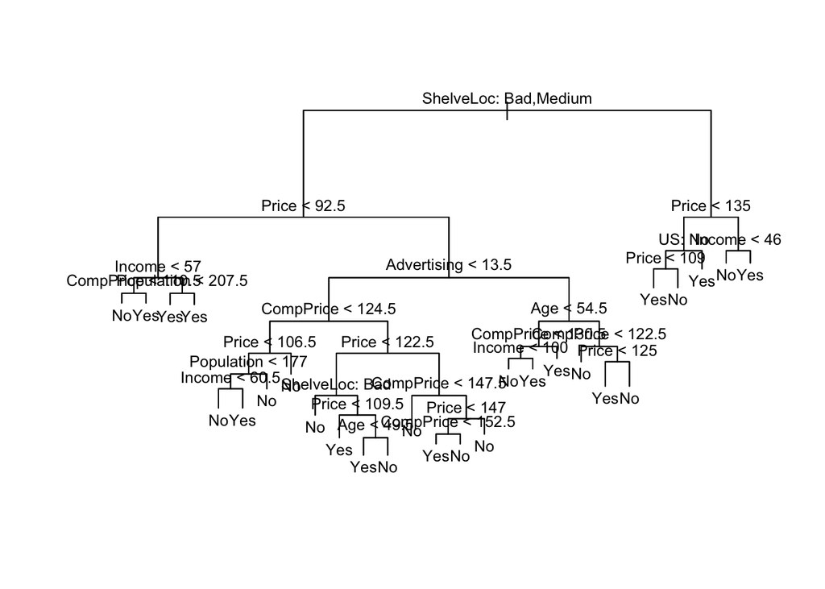

```r
plot(tree.carseats)
#Para agragar los textos
text(tree.carseats, pretty=0, cex=0.8)
```

El indicador más importante de *Sales* parece ser la ubicación de *ShelveLoc*, ya que la primera rama diferencia *Good* ubicaciones de las Ubicaciones de *Bad* y *Medium*. Si simplemente escribimos el nombre del objeto del árbol, R imprime la salida correspondiente a cada rama del árbol. R Muestra el criterio de división (por ejemplo, *Price* <92.5), luego el número de observaciones en esa rama, la desviación, la predicción general de la rama (Sí o No) y la fracción de observaciones en esa rama que toman valores de Sí y No. Las ramas que conducen a nodos terminales se indican mediante asteriscos.

```r
#Al escribir el nombre del objeto nos dará cada una de las ramas que tiene el arbol y así observar los predictores de nuestra función
tree.carseats
```

```
## node), split, n, deviance, yval, (yprob)
##       * denotes terminal node
##
##   1) root 400 541.500 No ( 0.59000 0.41000 )
##     2) ShelveLoc: Bad,Medium 315 390.600 No ( 0.68889 0.31111 )
##       4) Price < 92.5 46  56.530 Yes ( 0.30435 0.69565 )
##         8) Income < 57 10  12.220 No ( 0.70000 0.30000 )
##          16) CompPrice < 110.5 5   0.000 No ( 1.00000 0.00000 ) *
##          17) CompPrice > 110.5 5   6.730 Yes ( 0.40000 0.60000 ) *
##         9) Income > 57 36  35.470 Yes ( 0.19444 0.80556 )
##          18) Population < 207.5 16  21.170 Yes ( 0.37500 0.62500 ) *
##          19) Population > 207.5 20   7.941 Yes ( 0.05000 0.95000 ) *
##       5) Price > 92.5 269 299.800 No ( 0.75465 0.24535 )
##        10) Advertising < 13.5 224 213.200 No ( 0.81696 0.18304 )
##          20) CompPrice < 124.5 96  44.890 No ( 0.93750 0.06250 )
##            40) Price < 106.5 38  33.150 No ( 0.84211 0.15789 )
##              80) Population < 177 12  16.300 No ( 0.58333 0.41667 )
##               160) Income < 60.5 6   0.000 No ( 1.00000 0.00000 ) *
##               161) Income > 60.5 6   5.407 Yes ( 0.16667 0.83333 ) *
##              81) Population > 177 26   8.477 No ( 0.96154 0.03846 ) *
##            41) Price > 106.5 58   0.000 No ( 1.00000 0.00000 ) *
##          21) CompPrice > 124.5 128 150.200 No ( 0.72656 0.27344 )
##            42) Price < 122.5 51  70.680 Yes ( 0.49020 0.50980 )
##              84) ShelveLoc: Bad 11   6.702 No ( 0.90909 0.09091 ) *
##              85) ShelveLoc: Medium 40  52.930 Yes ( 0.37500 0.62500 )
##               170) Price < 109.5 16   7.481 Yes ( 0.06250 0.93750 ) *
##               171) Price > 109.5 24  32.600 No ( 0.58333 0.41667 )
##                 342) Age < 49.5 13  16.050 Yes ( 0.30769 0.69231 ) *
##                 343) Age > 49.5 11   6.702 No ( 0.90909 0.09091 ) *
##            43) Price > 122.5 77  55.540 No ( 0.88312 0.11688 )
##              86) CompPrice < 147.5 58  17.400 No ( 0.96552 0.03448 ) *
##              87) CompPrice > 147.5 19  25.010 No ( 0.63158 0.36842 )
##               174) Price < 147 12  16.300 Yes ( 0.41667 0.58333 )
##                 348) CompPrice < 152.5 7   5.742 Yes ( 0.14286 0.85714 ) *
##                 349) CompPrice > 152.5 5   5.004 No ( 0.80000 0.20000 ) *
##               175) Price > 147 7   0.000 No ( 1.00000 0.00000 ) *
##        11) Advertising > 13.5 45  61.830 Yes ( 0.44444 0.55556 )
##          22) Age < 54.5 25  25.020 Yes ( 0.20000 0.80000 )
##            44) CompPrice < 130.5 14  18.250 Yes ( 0.35714 0.64286 )
##              88) Income < 100 9  12.370 No ( 0.55556 0.44444 ) *
##              89) Income > 100 5   0.000 Yes ( 0.00000 1.00000 ) *
##            45) CompPrice > 130.5 11   0.000 Yes ( 0.00000 1.00000 ) *
##          23) Age > 54.5 20  22.490 No ( 0.75000 0.25000 )
##            46) CompPrice < 122.5 10   0.000 No ( 1.00000 0.00000 ) *
##            47) CompPrice > 122.5 10  13.860 No ( 0.50000 0.50000 )
##              94) Price < 125 5   0.000 Yes ( 0.00000 1.00000 ) *
##              95) Price > 125 5   0.000 No ( 1.00000 0.00000 ) *
##     3) ShelveLoc: Good 85  90.330 Yes ( 0.22353 0.77647 )
##       6) Price < 135 68  49.260 Yes ( 0.11765 0.88235 )
##        12) US: No 17  22.070 Yes ( 0.35294 0.64706 )
##          24) Price < 109 8   0.000 Yes ( 0.00000 1.00000 ) *
##          25) Price > 109 9  11.460 No ( 0.66667 0.33333 ) *
##        13) US: Yes 51  16.880 Yes ( 0.03922 0.96078 ) *
##       7) Price > 135 17  22.070 No ( 0.64706 0.35294 )
##        14) Income < 46 6   0.000 No ( 1.00000 0.00000 ) *
##        15) Income > 46 11  15.160 Yes ( 0.45455 0.54545 ) *
```

Para evaluar adecuadamente el rendimiento de un árbol de clasificación en estos datos, debemos estimar el error de prueba en lugar de simplemente calcular el error de entrenamiento.

Lo que tenemos que hacer es divir las observaciones en un conjunto de entrenamiento y un conjunto de prueba, como ya lo hemos hecho en otros métodos, construimos el árbol usando el conjunto de entrenamiento y evaluamos su desempeño en los datos de la prueba. La función *predict()* se puede usar para este propósito. En el caso de un árbol de clasificación, el argumento *type=“class”* instruye a R para que devuelva la predicción de clase real.

```r
#Estimamos el error con un conjunto de entrenamiento y uno de prueba
set.seed(123)
train<-sample(1:nrow(Carseats), 200)
#toma todos los datos que no sean variabled de train
Carseats.test<-Carseats[-train, ]
#De la vairable high toma todos los que nos son de entrenaiento
High.test<-High[-train]
#arbol con argumento extra donde especificamos que se debe de hacer con el conjunto de entrenamiento
tree.carseats<-tree(High~.-Sales,Carseats,subset=train)
#Predicción para probar el modelo en el conjunto de prueba, se agrega el type=class para que nos regrese una predicción de clase real
tree.pred<-predict(tree.carseats,Carseats.test,type="class")
#Matriz de confusión
table(tree.pred,High.test)
```

```
##          High.test
## tree.pred No Yes
##       No  87  13
##       Yes 35  65
```

```r
(87+65)/200
```

```
## [1] 0.76
```

El 76% de las predicciones se realizaron correctamente. A continuación, consideramos si podar el árbol podría conducir a mejores resultados.

Para este fin la función *cv.tree()* realiza una validación cruzada para que determine el nivel óptimo de complejidad del árbol; Se utiliza poda de complejidad de costos para seleccionar una secuencia de árboles para su consideración. Usamos el argumento *FUN=prune.misclass* para indicar que queremos que la tasa de error de clasificación guíe el proceso de validación cruzada y poda. La función *cv.tree()* informa el número de nodos terminales de cada árbol considerado (tamaño), así como la tasa de error correspondiente y el valor del parámetro de costo-complejidad utilizado.

```r
#Validación cruzada, usamos cv.tree para obtener la validación cruzada del modelo en el que utilizamos el arbol de decisión
set.seed(123)
#Utilizamos el conjunto de entrenamiento
#prune.misclass para que la tasa de error de la clasificación nos guíe en el proceso de validación obteniendo el arbol más pequeño posbible
cv.carseats<-cv.tree(tree.carseats,FUN=prune.misclass)
names(cv.carseats)
```

```
## [1] "size"   "dev"    "k"      "method"
```

```r
#dev tasa de error de la validación cruzada
cv.carseats
```

```
## $size
## [1] 20 18 16 13  8  3  2  1
##
## $dev
## [1] 74 75 75 74 75 75 91 93
##
## $k
## [1]      -Inf  0.000000  0.500000  1.333333  2.000000  3.000000 13.000000
## [8] 20.000000
##
## $method
## [1] "misclass"
##
## attr(,"class")
## [1] "prune"         "tree.sequence"
```

Noten que *dev* corresponde a la tasa de error de validación cruzada. ¿Cuál es el nodo del árbol con el valor mínimo de tasa de error? Trazamos la tasa de error en función del tamaño.

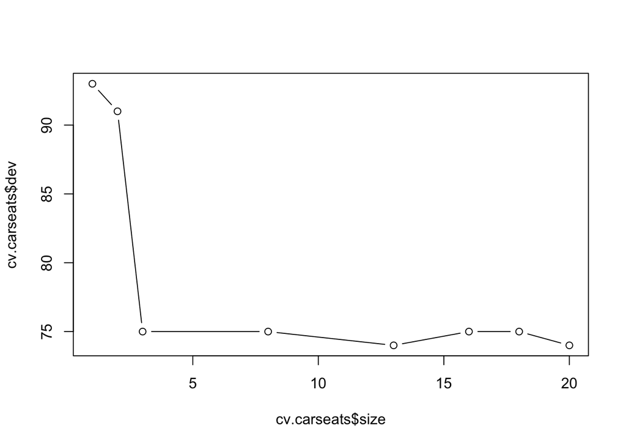

```r
#ploteamos el resultado de carseats donde hicimos la validación cruzada
plot(cv.carseats$size ,cv.carseats$dev ,type="b")
```

Aplicamos la función *prune.misclass()* para podar el árbol.

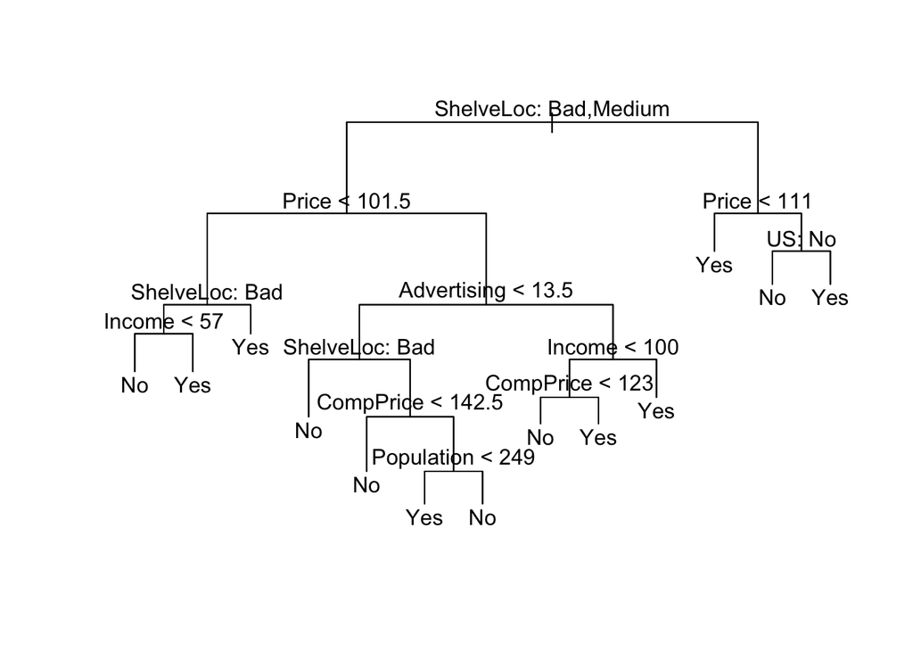

```r
prune.carseats<-prune.misclass(tree.carseats,best=13)
plot(prune.carseats)
text(prune.carseats,pretty=0)
```

¿Qué tan bien funciona este árbol podado en el conjunto de datos de prueba? Una vez más, aplicamos la función *predict ()*

```r
tree.pred<-predict(prune.carseats,Carseats.test,type="class")
table(tree.pred,High.test)
```

```
##          High.test
## tree.pred No Yes
##       No  86  13
##       Yes 36  65
```

```r
#3
(85+58)/200
```

```
## [1] 0.715
```

```r
#8
(88+66)/200
```

```
## [1] 0.77
```

```r
#13
(86+65)/200
```

```
## [1] 0.755
```

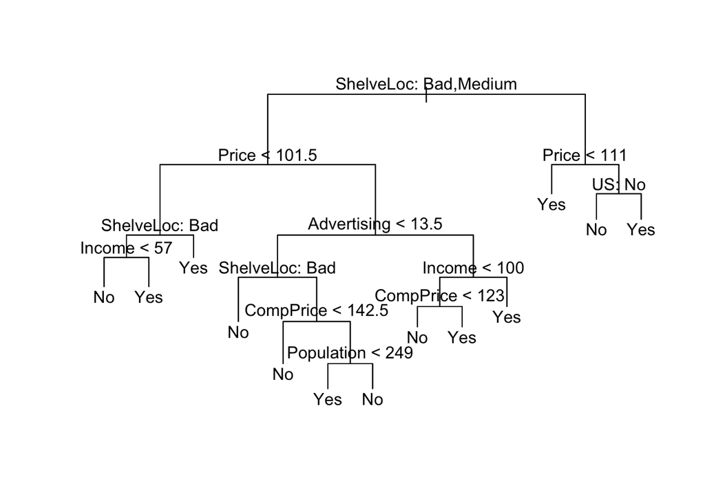

```r
prune.carseats<-prune.misclass(tree.carseats, best=13)
plot(prune.carseats)
text(prune.carseats, pretty=0)
```

```r
tree.pred<-predict(prune.carseats, Carseats.test, type="class")
table(tree.pred, High.test)
```

```
##          High.test
## tree.pred No Yes
##       No  86  13
##       Yes 36  65
```

```r
(86+65)/200
```

```
## [1] 0.755
```

### 2. Ajuste de árboles de regresión

Aquí ajustamos un árbol de regresión al conjunto de datos de Boston. Primero, creamos un conjunto de entrenamiento y ajustamos el árbol a los datos de entrenamiento

```r
library(MASS)
set.seed(123)
#Para la función trrain estamos utilizando la mitad del conjuntos de datos
train <- sample(1:nrow(Boston), nrow(Boston)/2)
Boston.data.test<-Boston[-train, ]
#Se tiene que revisar si funciona el signo de exclamación o menos
tree.boston<-tree(medv~., data=Boston, subset=train)
summary(tree.boston)
```

```
##
## Regression tree:
## tree(formula = medv ~ ., data = Boston, subset = train)
## Variables actually used in tree construction:
## [1] "rm"    "lstat" "crim"  "tax"
## Number of terminal nodes:  8
## Residual mean deviance:  12.98 = 3179 / 245
## Distribution of residuals:
##      Min.   1st Qu.    Median      Mean   3rd Qu.      Max.
## -11.86000  -1.99500   0.03714   0.00000   1.86800  16.45000
```

Observe que la salida de *summary ()* indica que solo cuatro de las variables se han utilizado para construir el árbol. En el contexto de un árbol de regresión, la desviación es simplemente la suma de los errores al cuadrado del árbol. Ahora trazamos el árbol.

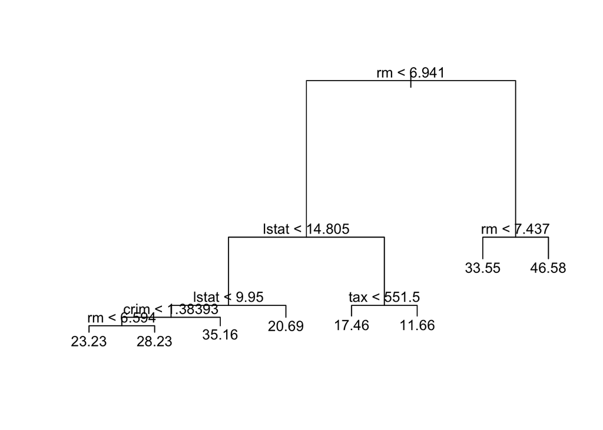

```r
#Plot del arbol de regresión
plot(tree.boston)
text(tree.boston, pretty=0)
```

La variable *rm* representa el número medio de habitaciones por vivienda, *lstat* mide el porcentaje de individuos con un estado socioeconómico más bajo. El árbol indica que entre mayor sea el número de habitaciones las casas son más caras, así como los valores más bajos de *lstat* corresponden a las casas más caras. Ahora utilizamos la función *cv.tree()* para ver si podar el árbol mejorará el rendimiento

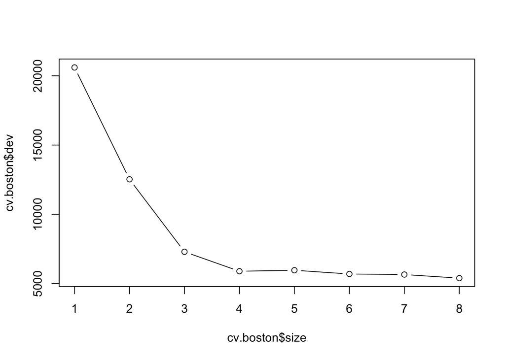

```r
#Validación para ver si se puede hacer un mejor arbol
cv.boston<-cv.tree(tree.boston)
plot(cv.boston$size, cv.boston$dev, type="b")
```

En este caso, el árbol más complejo se selecciona mediante validación cruzada. Sin embargo, si deseamos podar el árbol, podríamos hacerlo de la siguiente manera, utilizando la función *prune.tree ()*:

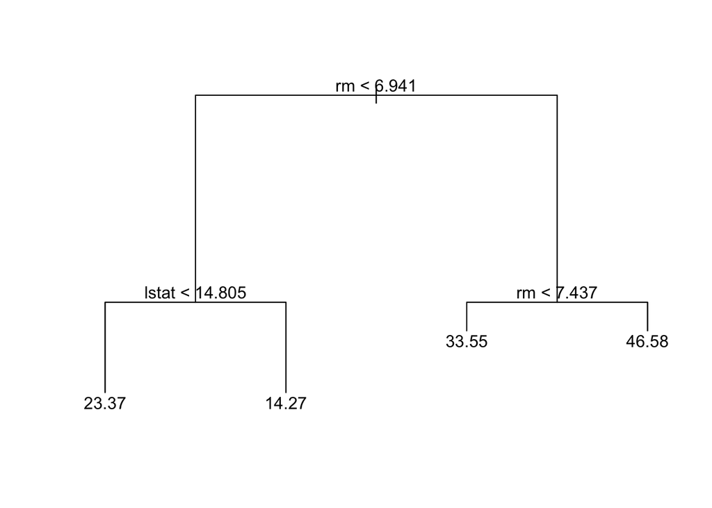

```r
#Podar con la función prune.tree
prune.boston<-prune.tree(tree.boston, best=4)
plot(prune.boston)
text(prune.boston, pretty=0)
```

De acuerdo con los resultados de la validación cruzada, utilizamos las predicciones de árbol sin podar para hacer predicciones en el conjunto de prueba

```r
tree.boston
```

```
## node), split, n, deviance, yval
##       * denotes terminal node
##
##  1) root 253 20510.0 22.55
##    2) rm < 6.941 219  8862.0 20.13
##      4) lstat < 14.805 141  3385.0 23.37
##        8) lstat < 9.95 82  2169.0 25.30
##         16) crim < 1.38393 77   908.5 24.66
##           32) rm < 6.594 55   341.3 23.23 *
##           33) rm > 6.594 22   173.6 28.23 *
##         17) crim > 1.38393 5   743.0 35.16 *
##        9) lstat > 9.95 59   488.6 20.69 *
##      5) lstat > 14.805 78  1313.0 14.27
##       10) tax < 551.5 35   273.4 17.46 *
##       11) tax > 551.5 43   390.3 11.66 *
##    3) rm > 6.941 34  2085.0 38.15
##      6) rm < 7.437 22   607.1 33.55 *
##      7) rm > 7.437 12   161.7 46.58 *
```

```r
#Predicción para obtener el valor medio de las casas
boston.pred<-predict(tree.boston, newdata=Boston.data.test)
boston.test<-Boston[-train,"medv"]
sqrt(mean((boston.pred-boston.test)^2))
```

```
## [1] 4.848972
```

La raíz cuadrada del *MSE*, indica que este modelo conduce a predicciones de prueba que están dentro del valor medio real de la vivienda para el suburbio.

### 3. Bagging and Random Forests

Aquí aplicamos *Bagging* y *Random Forests* a los datos Boston, usando la librería *randomForest* en R. Los resultados exactos obtenidos en esta sección pueden depender de la versión de R y de la versión del paquete *randomForest()* instalado en su computadora. Recuerde que el *Bagging* es simplemente un caso especial de un *Random Forests* con $m = p$. Por lo tanto, la función *randomForest ()* se puede utilizar para realizar *Random Forests* y *Bagging*. Realizamos *Bagging* como sigue

```r
#Bagging es un tipo de random forest
library(randomForest)
set.seed(123)
#mtry es para que considere los 13 predictores sean parte del árbol, importance true para que de la importancia de cada una de las variables dentro del modelo
bag.boston<-randomForest(medv~.,data=Boston,subset=train,mtry=13,importance=TRUE)
bag.boston
```

```
##
## Call:
##  randomForest(formula = medv ~ ., data = Boston, mtry = 13, importance = TRUE,      subset = train)
##                Type of random forest: regression
##                      Number of trees: 500
## No. of variables tried at each split: 13
##
##           Mean of squared residuals: 13.59049
##                     % Var explained: 83.23
```

El argumento *mtry= 13* indica que los 13 predictores deben ser considerados para cada división del árbol. ¿Qué tan bien se desempeña este modelo sobre el set de prueba?

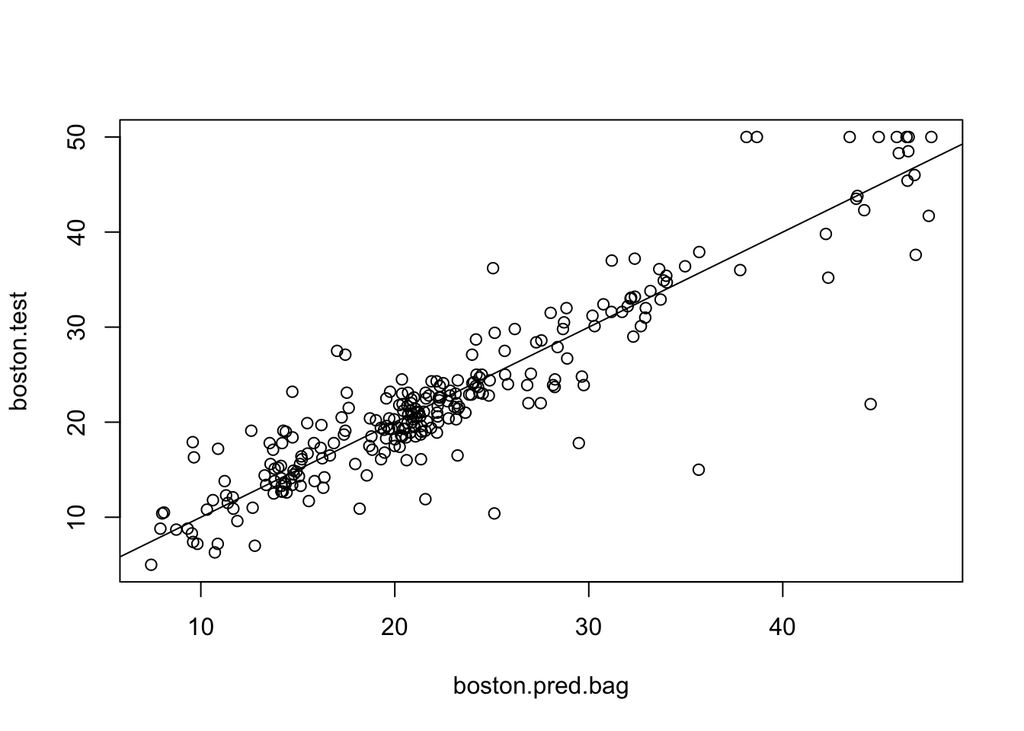

```r
#Realizar la comparación con el conjunto de prueba
boston.pred.bag <- predict(bag.boston, newdata=Boston.data.test)
#Diferencia
plot(boston.pred.bag, boston.test)
abline(0,1)
```

```r
#Calcular el valor medio al cuadrado
mean((boston.pred.bag-boston.test)^2)
```

```
## [1] 14.82658
```

¿Cual es el MSE asociado con el árbol de regresión en bagging? Podríamos cambiar el número de árboles cultivados por *RandomForest()* usando el argumento siguiente *ntree*:

```r
#Correr con menos para ver si se reduce el error
#ntree para indicar el número de árboles que quiero
set.seed(123)
bag.boston<-randomForest(medv~.,data=Boston,subset=train,mtry=13,ntree=25)
boston.pred.bag <- predict(bag.boston, newdata=Boston.data.test)
mean((boston.pred.bag-boston.test)^2)
```

```
## [1] 14.55574
```

El crecimiento de un *Random Forests* procede exactamente de la misma manera, excepto que usamos un valor menor de su argumento. Por defecto, *randomForest()* usa variables $p / 3$ cuando construye un bosque aleatorio de árboles de regresión y $\sqrt{p}$ variables cuando construye un bosque aleatorio de árboles de clasificación. Aquí usamos *mtry = 6*.

```r
#Disminuir el número de predictores a 6
set.seed(123)
rf.boston<-randomForest(medv~.,data=Boston,subset=train,mtry=6,importance =TRUE)
boston.pred.rf <- predict(rf.boston ,newdata=Boston.data.test)
mean((boston.pred.rf-boston.test)^2)
```

```
## [1] 12.76183
```

¿Cual es el valor del conjunto de prueba *MSE*? ¿se mejoró?; Usando la función *importance ()*, podemos ver la importancia de cada variable y se pueden generar gráficos de estas medidas importantes utilizando la función *varImpPlot()*.

```r
#Conocer la importancia de los predictores que se están utilizando
importance(rf.boston)
```

```
##           %IncMSE IncNodePurity
## crim    12.697705    1439.85189
## zn       1.948040      54.09570
## indus    6.850607     596.16940
## chas     2.404661      75.58075
## nox     10.815893     703.32507
## rm      32.755672    7305.23476
## age     10.222574     515.34594
## dis     13.608222    1112.04788
## rad      4.600246     131.35233
## tax      9.239586     508.45391
## ptratio  9.690679     717.36922
## black    5.722377     301.14534
## lstat   29.112077    6743.11775
```

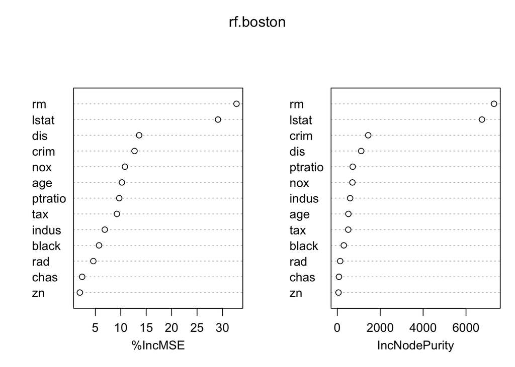

```r
varImpPlot(rf.boston)
```

Se muestran dos medidas de variables de importancia. El primero se basa en la disminución media de la precisión en las predicciones de las muestras fuera de bagging cuando una variable dada se excluye del modelo. Esta última es una medida de la disminución total en la impureza de los nodos que resulta de las divisiones sobre esa variable, promediada sobre todos los árboles. En el caso de los árboles de regresión, la impureza del nodo se mide por el RSS de entrenamiento, y para los árboles de clasificación por la desviación.

Los resultados indican que en todos los árboles considerados en el bosque aleatorio, el nivel de riqueza de la comunidad (*lstat*) y el tamaño de la casa (*rm*) son por mucho las dos variables más importantes para el valor medio de la casa.

### 4. Boosting

Aquí usamos la libreria *gbm*, y dentro de la función *gbm()*, para ajustar los árboles de regresión al conjunto de datos *Boston*. Ejecutamos *gbm()* con la opción de *distribution=“gaussiano”* ya que este es un problema de regresión; si se tratara de un problema de clasificación binaria, utilizaríamos *distribution=“bernoulli”*. El argumento *n.trees=5000* indica que queremos 5000 árboles, y la opción *interaction.depth=4* limita la profundidad de cada árbol. Tome en cuenta que para la función gbm no es posible utilizar el argumento *subset=train*, así que desde el argumento del conjunto de datos hay que seleccionar sólo las observaciones de entrenamiento.

```r
library(gbm)
#Hace una interacción mucho más grande de la información para obtener resultados más confiables
set.seed(123)
#Aquí el conjunto de datos se pone directamente
boost.boston<-gbm(medv~.,data=Boston[train,],
                  distribution="gaussian",n.trees=5000,interaction.depth=4)
#Para árbol de regresión se utiliza gaussian
#Para árbol de clasificación se utiliza "bernoulli"
```

La función *summary ()* produce un gráfico y las estadísticas de influencia relativa.

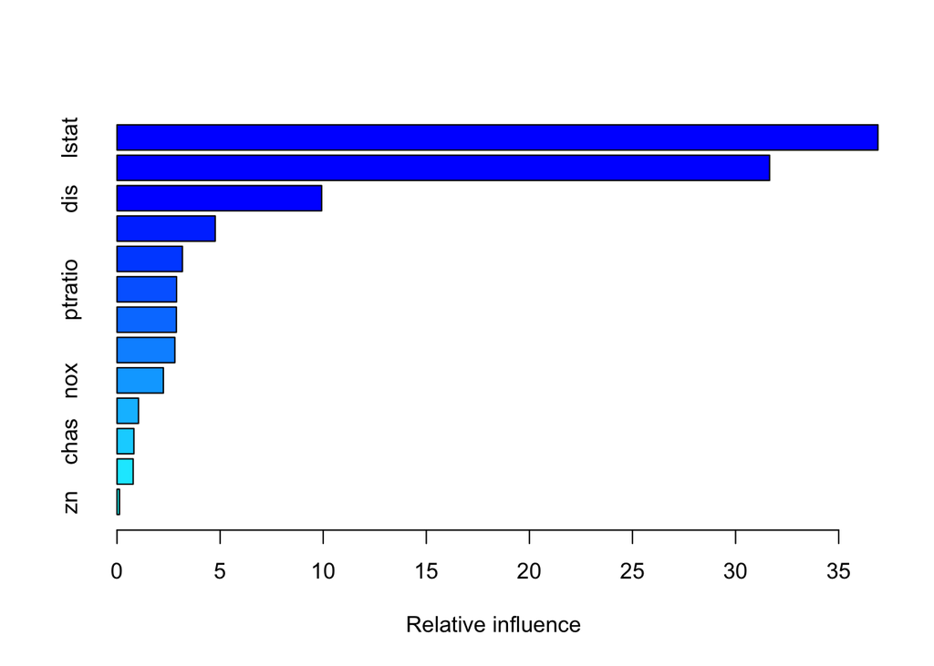

```
##             var    rel.inf
## lstat     lstat 36.9047193
## rm           rm 31.6492543
## dis         dis  9.9236656
## crim       crim  4.7636681
## age         age  3.1727355
## ptratio ptratio  2.8884337
## black     black  2.8779828
## tax         tax  2.8055114
## nox         nox  2.2500602
## indus     indus  1.0427958
## chas       chas  0.8189095
## rad         rad  0.7834895
## zn           zn  0.1187742
```

```r
summary(boost.boston)
```

Vemos que *lstat* y *rm* son por mucho las variables más importantes. También podemos producir gráficos de dependencia parcial para estas dos variables. Estas gráficas de dependencia parcial ilustran el efecto marginal de las variables seleccionadas sobre la respuesta después de integrar las otras variables. En este caso, como podríamos esperar, los precios medios de las casas están aumentando con *rm* y disminuyendo con *lstat*.

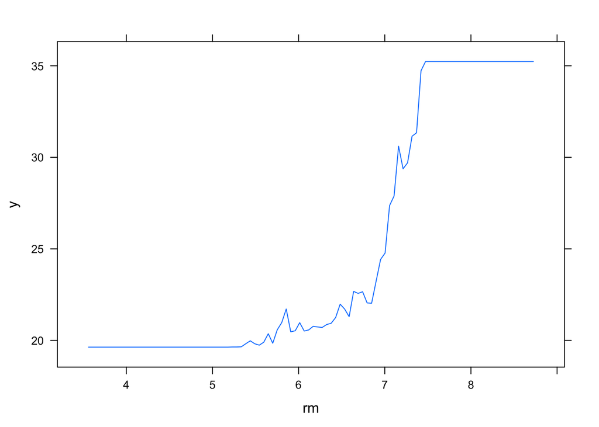

```r
par(mfrow=c(1,2))
#Plot solo de las variables más importantes
plot(boost.boston, i="rm")
```

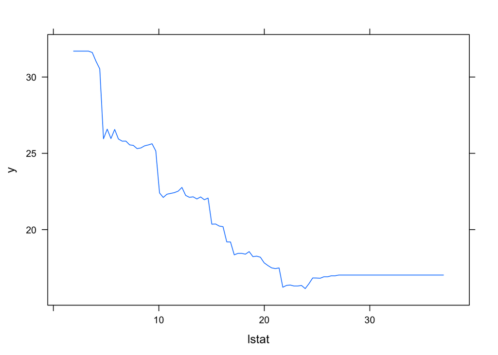

```r
plot(boost.boston, i="lstat")
```

### 5. Resuelve

Este problema tiene que ver con el conjunto de datos OJ que forma parte del paquete ISLR.

1. Crea un conjunto de entrenamiento que contenga una muestra aleatoria de 800 observaciones y un conjunto de pruebas que contenga las observaciones restantes. Utilice una semilla de 555.

```r
library(tree)
library(ISLR)
attach(OJ)
summary(OJ)
```

```
##  Purchase WeekofPurchase     StoreID        PriceCH         PriceMM
##  CH:653   Min.   :227.0   Min.   :1.00   Min.   :1.690   Min.   :1.690
##  MM:417   1st Qu.:240.0   1st Qu.:2.00   1st Qu.:1.790   1st Qu.:1.990
##           Median :257.0   Median :3.00   Median :1.860   Median :2.090
##           Mean   :254.4   Mean   :3.96   Mean   :1.867   Mean   :2.085
##           3rd Qu.:268.0   3rd Qu.:7.00   3rd Qu.:1.990   3rd Qu.:2.180
##           Max.   :278.0   Max.   :7.00   Max.   :2.090   Max.   :2.290
##      DiscCH            DiscMM         SpecialCH        SpecialMM
##  Min.   :0.00000   Min.   :0.0000   Min.   :0.0000   Min.   :0.0000
##  1st Qu.:0.00000   1st Qu.:0.0000   1st Qu.:0.0000   1st Qu.:0.0000
##  Median :0.00000   Median :0.0000   Median :0.0000   Median :0.0000
##  Mean   :0.05186   Mean   :0.1234   Mean   :0.1477   Mean   :0.1617
##  3rd Qu.:0.00000   3rd Qu.:0.2300   3rd Qu.:0.0000   3rd Qu.:0.0000
##  Max.   :0.50000   Max.   :0.8000   Max.   :1.0000   Max.   :1.0000
##     LoyalCH          SalePriceMM     SalePriceCH      PriceDiff       Store7
##  Min.   :0.000011   Min.   :1.190   Min.   :1.390   Min.   :-0.6700   No :714
##  1st Qu.:0.325257   1st Qu.:1.690   1st Qu.:1.750   1st Qu.: 0.0000   Yes:356
##  Median :0.600000   Median :2.090   Median :1.860   Median : 0.2300
##  Mean   :0.565782   Mean   :1.962   Mean   :1.816   Mean   : 0.1465
##  3rd Qu.:0.850873   3rd Qu.:2.130   3rd Qu.:1.890   3rd Qu.: 0.3200
##  Max.   :0.999947   Max.   :2.290   Max.   :2.090   Max.   : 0.6400
##    PctDiscMM        PctDiscCH       ListPriceDiff       STORE
##  Min.   :0.0000   Min.   :0.00000   Min.   :0.000   Min.   :0.000
##  1st Qu.:0.0000   1st Qu.:0.00000   1st Qu.:0.140   1st Qu.:0.000
##  Median :0.0000   Median :0.00000   Median :0.240   Median :2.000
##  Mean   :0.0593   Mean   :0.02731   Mean   :0.218   Mean   :1.631
##  3rd Qu.:0.1127   3rd Qu.:0.00000   3rd Qu.:0.300   3rd Qu.:3.000
##  Max.   :0.4020   Max.   :0.25269   Max.   :0.440   Max.   :4.000
```

```r
set.seed(555)
train<-sample(1:nrow(OJ), 800)
OJ.test<-OJ[-train, ]
```

2. Ajusta un árbol a los datos de entrenamiento, con Purchase como la respuesta y las otras variables como predictores. Utilice la función summary() para producir estadísticas resumidas sobre el árbol, y describa los resultados obtenidos. ¿Cuál es la tasa de error de entrenamiento? ¿Cuántos nodos terminales tiene el árbol?

```r
tree.OJ<-tree(Purchase~.,OJ,subset=train)
summary(tree.OJ)
```

```
##
## Classification tree:
## tree(formula = Purchase ~ ., data = OJ, subset = train)
## Variables actually used in tree construction:
## [1] "LoyalCH"       "PriceDiff"     "SpecialCH"     "ListPriceDiff"
## Number of terminal nodes:  9
## Residual mean deviance:  0.6834 = 540.5 / 791
## Misclassification error rate: 0.1375 = 110 / 800
```

```r
#Se puede apreciar que la tasa de error de entrenamiento es de 13.75% y la cantidad de nodos terminales del árbol es de 9
```

3. Crea una gráfica del árbol, e interpreta los resultados.

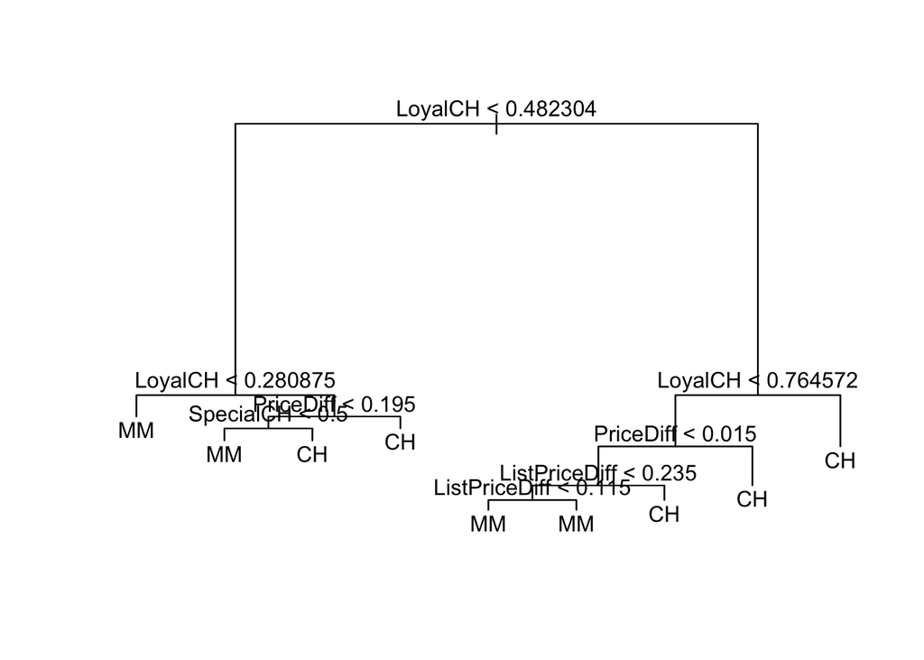

```r
plot(tree.OJ)
text(tree.OJ, pretty=0)
```

```r
#Gracias a la gráfica se puede apreciar que la variable más significativa para explicar si alguien eligió comprar Citrus Hill o Minute Maid es LoyalCH que indica la fidelidad de los clientes a la marca Citrus Hill
#Posteriormente, la variable más significativa es la diferencia de precios entre una marca y otra.
```

4. Predice la respuesta en los datos de la prueba, y producir una matriz de confusión comparando las etiquetas de la prueba con las etiquetas de la prueba pronosticada. ¿Cuál es la tasa de error de la prueba?

```r
OJ.pred<-predict(tree.OJ,newdata=OJ.test, type = "class")
table(OJ.pred,OJ.test$Purchase)
```

```
##
## OJ.pred  CH  MM
##      CH 129  31
##      MM  28  82
```

```r
#Gracias a la matriz de confusión podemos sacar la tasa de error de la prueba
(28+31)/270
```

```
## [1] 0.2185185
```

```r
#La tasa de error de la prueba es del 21.8%
```

5. Aplica la función cv.tree() al conjunto de entrenamiento para determinar el tamaño óptimo del árbol.

```r
cv.tree.OJ<-cv.tree(tree.OJ,FUN=prune.misclass)
```

6. Produce un gráfico con el tamaño del árbol en el eje x y la tasa de error de clasificación cruzada en el eje y.

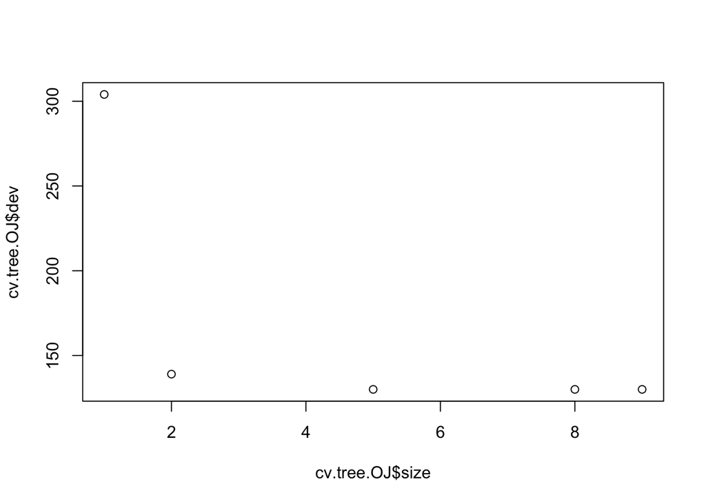

```r
plot(cv.tree.OJ$size,cv.tree.OJ$dev)
```

7. ¿Qué tamaño de árbol corresponde a la menor tasa de error de clasificación validada cruzada?

```r
#Con ayuda de la gráfica se puede apreciar que el tamaño de árbol que corresponde a la menor tasa de error de clasificación es el 5. Sin embargo, podemos apreciar que el cambio más significativo se da en el tamaño dos, por lo que podríamos optar por ese ya que es el que representa una menor tasa de error sin hacer tan compleja nuestra ramificación.
```

8. Produce un árbol podado que corresponda al tamaño óptimo de árbol obtenido mediante validación cruzada. Si la validación cruzada no conduce a la selección de un árbol podado, crea un árbol podado con cinco nodos terminales.

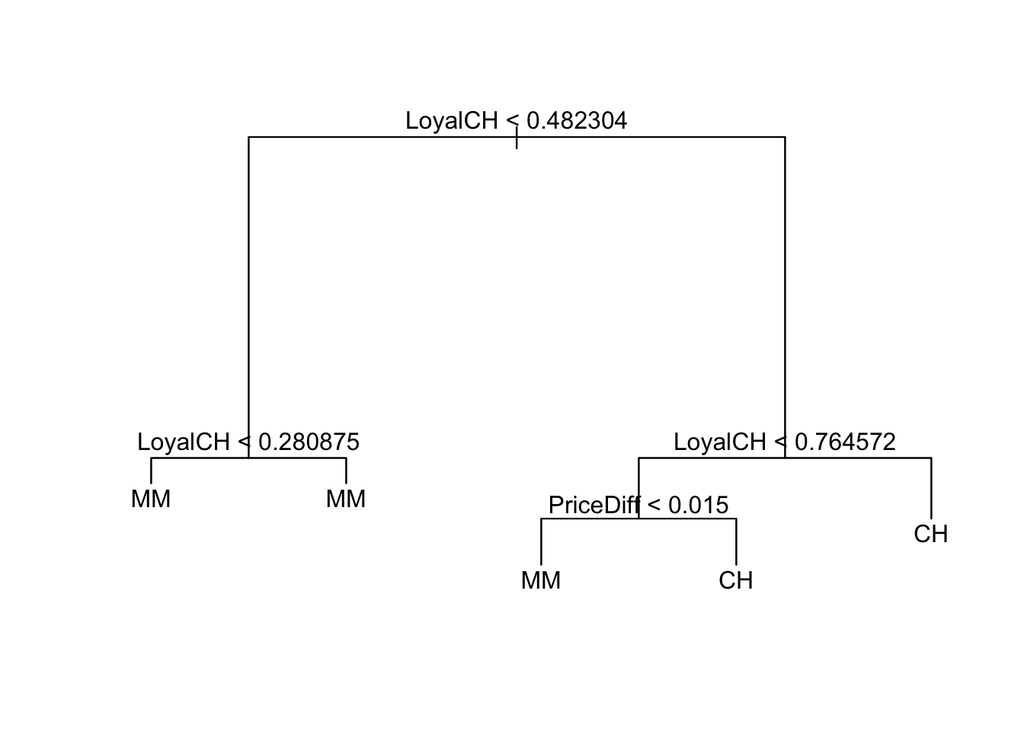

```r
#La validación cruzada realizada previamente nos indica que el más óptimo de los árboles generados es el que tiene 5 nodos. Por lo cuál, se crea el sieguiente árbol que toma en consideración las variables más significativas, siendo estas la fidelidad de los clientes a la marca Citrus Hill (LoyalCH) y la diferencia de precios entre Citrus Hill y Minute Maid (PriceDiff)
prune.OJ<-prune.tree(tree.OJ, best=5)
plot(prune.OJ)
text(prune.OJ, pretty=0)
```